# Lecture 6: Exploratory Data Analysis

PSTAT100: Data Science - Concepts and Analysis

John Inston

johninston@ucsb.edu

University of California, Santa Barbara

October 16, 2026

## 🚁 Overview

### Aims of the lecture

- Perform **exploratory data analysis (EDA)** to understand data **properties** and **relationships**.
- Use and understand **descriptive statistics**:
  - **Location** measures (mean, median, mode).
  - **Spread** measures (variance, standard deviation, IQR).
  - **Shape** measures (skewness, kurtosis).
- Use **data visualizations**:
  - Histograms, box plots, scatter plots, heatmaps, etc.
  - Understand distributions.

### 📚 Required Libraries

In this lecture we will be using the following libraries:

```python
import pandas as pd
import numpy as np
import matplotlib.pyplot as plt
import seaborn as sns
import altair as alt
```

### 💅 Figure Styles

```python
sns.set_style('whitegrid')
sns.set_palette('Set2')
```

# Exploratory Data Analysis (EDA)

## 🔍 Exploratory Data Analysis (EDA)

### What is EDA?

**Exploratory Data Analysis (EDA)**

**Exploratory Data Analysis (EDA)** is the process of analyzing and visualizing data to understand its structure, identify patterns, and uncover insights.

### EDA Steps

1. Perform **univariate analysis** to understand the distribution of individual variables.
2. Perform **multivariate analysis** to explore relationships between variables.
3. Develop insight to inform modelling and deeper analysis.

### Tools for EDA

- Descriptive statistics (**location**, **spread**, **shape**, **dependence**).
- Data visualization.

## EDA: Example Dataset

### Example Data Set: `titanic`

```python
import seaborn as sns
titanic = sns.load_dataset('titanic')
titanic.head()
```

|  | survived | pclass | sex | age | sibsp | parch | fare | embarked | class | who | adult_male | deck | embark_town | alive | alone |
| --- | --- | --- | --- | --- | --- | --- | --- | --- | --- | --- | --- | --- | --- | --- | --- |
| 0 | 0 | 3 | male | 22.0 | 1 | 0 | 7.2500 | S | Third | man | True | NaN | Southampton | no | False |
| 1 | 1 | 1 | female | 38.0 | 1 | 0 | 71.2833 | C | First | woman | False | C | Cherbourg | yes | False |
| 2 | 1 | 3 | female | 26.0 | 0 | 0 | 7.9250 | S | Third | woman | False | NaN | Southampton | yes | True |
| 3 | 1 | 1 | female | 35.0 | 1 | 0 | 53.1000 | S | First | woman | False | C | Southampton | yes | False |
| 4 | 0 | 3 | male | 35.0 | 0 | 0 | 8.0500 | S | Third | man | True | NaN | Southampton | no | True |

- The `titanic` dataset contains information about passengers on the Titanic.
- Collection of both categorical (e.g., `sex`, `class`) and numerical (e.g., `age`, `fare`) variables.

# Univariate Analysis

## EDA: Univariate Analysis

### What is Univariate Analysis?

- **Univariate analysis** focuses on analyzing and summarizing a single variable.
- Aim to understand:
  - **Location** (mean, median, mode).
  - **Variability** (standard deviation, interquartile range).
  - **Distribution shape** (skewness, kurtosis).
  - **Count** and **frequency** of categorical variables.

### Dependence on Variable Type

- Approach depends on the variable type:
  - **Quantitative** vs **Categorical** variables.
  - Changes the utility of different visualizations and statistics.

## Categorical Variables: Frequency and Proportions

### Statistics

- For categorical variables, we produce a table summarizing:
  - **Frequency**: The count of each category.
  - **Proportion**: The relative frequency of each category (frequency divided by total count).

### Example: Categorical Variable Summary Table

```python
pd.DataFrame({
  'Frequency': titanic['class'].value_counts(),
  'Proportion': titanic['class'].value_counts(normalize=True),
  'Percentage': titanic['class'].value_counts(normalize=True).mul(100).round(2).astype(str) + '%'
}).sort_index()
```

| class | Frequency | Proportion | Percentage |
| --- | --- | --- | --- |
| First | 216 | 0.242424 | 24.24% |
| Second | 184 | 0.206510 | 20.65% |
| Third | 491 | 0.551066 | 55.11% |

## Categorical Variables: Visualizations

### Visualization Options

- Our visualization options essentially just display this same information:
  - **Count Plot**: Displays the frequency or proportion of each category.
  - **Pie Chart**: Shows the proportion of each category as a slice of a pie.
    - Not generally recommended for accurate comparison, but can be useful for showing relative proportions.

### Example: Count Plot and Pie Chart

```python
colors = sns.color_palette('pastel')[0:3]
fig, ax = plt.subplots(nrows=1, ncols=2, figsize=(15, 4))
sns.countplot(
  data=titanic,
  x='class',
  ax=ax[0]
  )
ax[0].set(title='Count Plot', xlabel='Class', ylabel='Count')
ax[1].pie(
  titanic['class'].value_counts(),
  labels=titanic['class'].unique(),
  colors=colors,
  autopct='%.0f%%')
ax[1].set_title('Pie Chart of Passenger Class')
plt.tight_layout()
plt.show()
```

## Categorical Variables: Visualizations

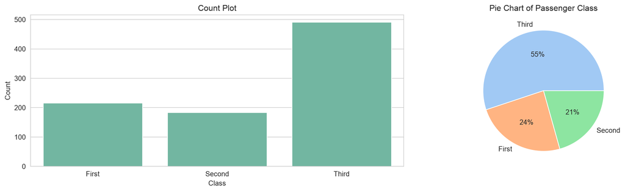

Count plot and pie chart for the `class` variable in the `titanic` dataset.

## Numerical Variables: Location Measures

### Mean

- For some numerical variable we have sample $x_1, ..., x_n$ of $n$ observations. The **sample mean** is computed as:
  $$\bar{x} := \frac{1}{n} \sum_{i=1}^n x_i.$$

### Median

- The **sample median** is the **middle value** of the **sorted data**.
  - If $n$ is **odd**, it is the value at position $\frac{n+1}{2}$.
  - If $n$ is **even**, it is the average of the values at positions $\frac{n}{2}$ and $\frac{n}{2}+1$.

### Mode

- The **sample mode** is the value that appears most frequently in the data.

## Example: Location Measures

- The mean is **sensitive to outliers**, while the median is more robust.
  - What if we add a value of 100?
- The mode can be useful for understanding the **most common value**, especially in categorical data.
  - Why might this stop being useful with `float` data?

## Numerical Variables: Spread Measures

### Variance and Standard Deviation

- The **sample variance** is computed as:
  $$s^2 := \frac{1}{n-1} \sum_{i=1}^n (x_i - \bar{x})^2.$$
  - This can be intuitively be thought of as the average squared distance of the data points from the mean.
  - We divide by $n-1$ instead of $n$ to get an unbiased estimate of the population variance (Bessel’s correction - discussed further next week).
- The **sample standard deviation** is the square root of the variance:
  $$s := \sqrt{s^2}.$$

## Min, Max, Range, and Interquartile Range

- It is often useful to understand the range of values in the data, as well as the spread of the middle 50% of the data.
- The **minimum** and **maximum** values provide the range of the data:
  $$\text{Range} := \max(x_i) - \min(x_i).$$
- A **quantile** is a cut point that divides a sorted dataset into **equal-sized groups**.
  - **Percentiles** are quantiles that divide the data into 100 equal parts.
  - **Quartiles** are quantiles that divide the data into 4 equal parts.
    - The **first quartile** (Q1) is the 25th percentile.
    - The **second quartile** (Q2) is the 50th percentile (the median).
    - The **third quartile** (Q3) is the 75th percentile.
- The **interquartile range (IQR)** is the difference between the third and first quartiles:
  $$\text{IQR} := Q3 - Q1.$$

## Numerical Data Summary and Box Plots

### Data Summary

- We can use the `describe()` method in pandas to compute most of the common summary statistics for a numerical variable.
- A **box plot** (or box-and-whisker plot) is a graphical representation of the summary statistics, showing the median, quartiles, and potential outliers.

### Example: Data Summary Table

```python
titanic['age'].describe()
```

```
count    714.000000
mean      29.699118
std       14.526497
min        0.420000
25%       20.125000
50%       28.000000
75%       38.000000
max       80.000000
Name: age, dtype: float64
```

### Example: Box Plot

```python
fig, ax = plt.subplots(figsize=(10, 5))
sns.boxplot(data=titanic, x='age', ax=ax)
ax.set_title('Box Plot of Passenger Age')
plt.tight_layout()
plt.show()
```

## Numerical Data Summary and Box Plots

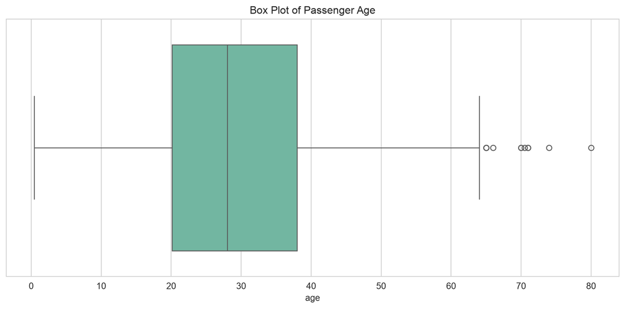

## Histograms

### Histograms

- Box plots are useful for summarizing the distribution of a numerical variable.
- **Histograms** are useful for visualizing the **shape** of the distribution.
  - A histogram divides the range of the data into **intervals (bins)** and counts the number of observations in each bin.
  - The choice of bin width can affect the appearance of the histogram and our interpretation of the data.

### Example: Histogram

```python
fig, ax = plt.subplots(figsize=(10, 5))
sns.histplot(data=titanic, x='age', bins=20, kde=True, ax=ax)
ax.set_title('Histogram of Passenger Age')
plt.tight_layout()
plt.show()
```

## Histograms

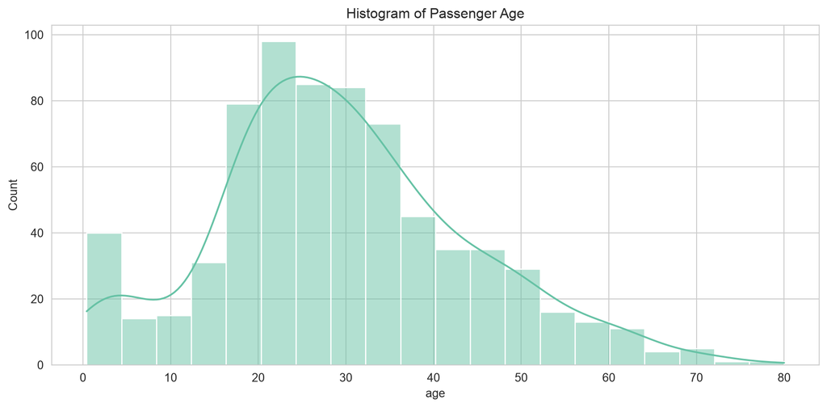

Histogram of the `age` variable in the `titanic` dataset.

## Histogram with Summary Statistic Overlays

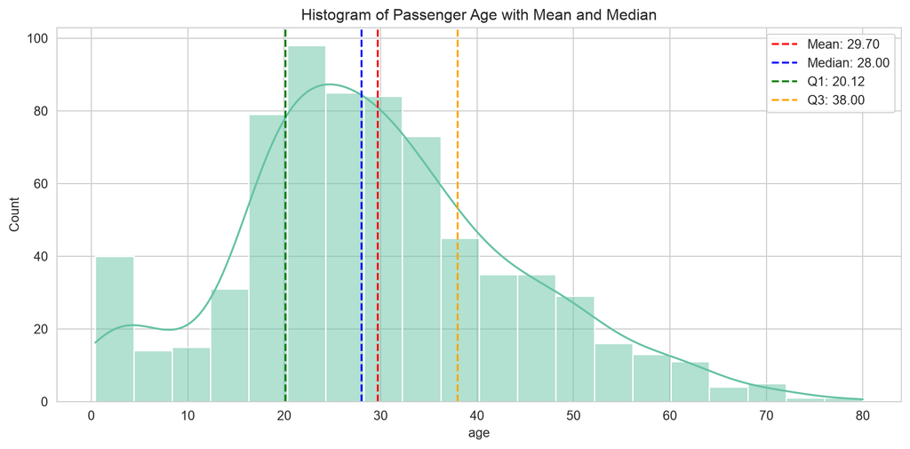

Histogram of the `age` variable in the `titanic` dataset with summary statistic overlays.

## Skewness

### Skewness

- **Skewness** measures the asymmetry of the distribution of a numerical variable.
  - A distribution is **positively skewed** (right-skewed) if it has a long tail on the right side.
  - A distribution is **negatively skewed** (left-skewed) if it has a long tail on the left side.
- The **skewness** can be calculated using the formula:
  $$\text{Skewness} = \frac{1}{n} \sum_{i=1}^n \left( \frac{x_i - \bar{x}}{s} \right)^3.$$

## Kurtosis

- **Kurtosis** measures the “tailedness” of the distribution of a numerical variable.
  - A distribution is **leptokurtic** if it has heavy tails and a sharp peak.
  - A distribution is **platykurtic** if it has light tails and a flat peak.
  - A distribution is **mesokurtic** if it has tails and a peak similar to the normal distribution.
- The **kurtosis** can be calculated using the formula:
  $$\text{Kurtosis} = \frac{1}{n} \sum_{i=1}^n \left( \frac{x_i - \bar{x}}{s} \right)^4.$$

## Example: Skewness and Kurtosis

### Skewness and Kurtosis Calculation

- There are built-in functions in libraries like `scipy.stats` to calculate skewness and kurtosis, but we can also implement these calculations manually using the formulas provided.

```python
def calculate_skewness_kurtosis(data):
    n = len(data)
    mean = np.mean(data)
    std_dev = np.std(data, ddof=1)  # Sample standard deviation
    skewness = (1/n) * np.sum(((data - mean) / std_dev) ** 3)
    kurtosis = (1/n) * np.sum(((data - mean) / std_dev) ** 4)
    return skewness, kurtosis
```

## Histogram with Kurtosis and Skewness

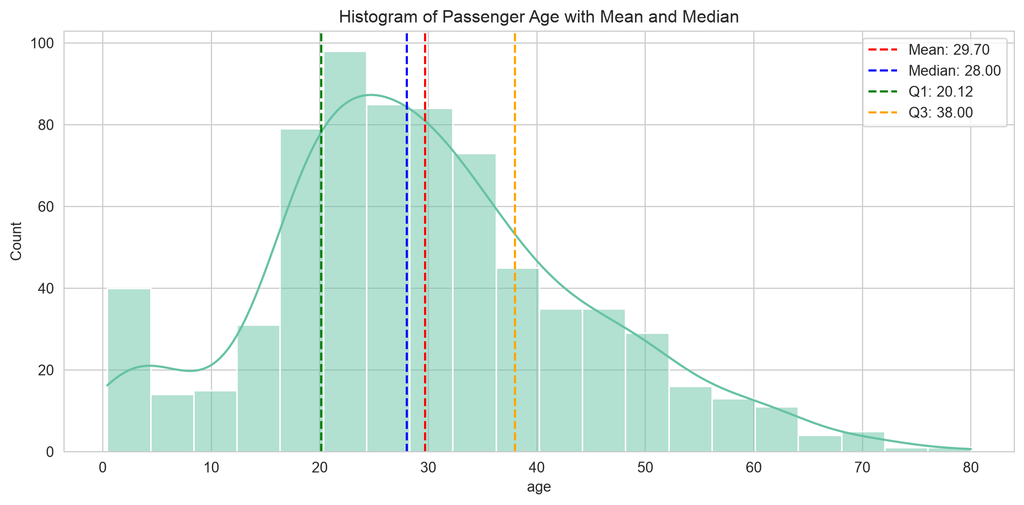

Histogram of the `age` variable in the `titanic` dataset with summary statistic overlays.

```python
skewness, kurtosis = calculate_skewness_kurtosis(titanic['age'].dropna())
print(f'Skewness: {skewness:.2f}, Kurtosis: {kurtosis:.2f}')
```

```
Skewness: 0.39, Kurtosis: 3.16
```

## Quick Note on the Normal Distribution

### What is the Normal Distribution?

- The **normal distribution** (or Gaussian distribution) is a continuous probability distribution that is symmetric around its mean, with a bell-shaped curve.
  - We will cover probability distributions in more detail next week but it is helpful to have an idea about the normal distribution when discussing skewness and kurtosis.
- It is defined by its mean ($\mu$) and standard deviation ($\sigma$).
- Many natural phenomena and measurement errors tend to follow a normal distribution, making it a fundamental concept in statistics.

### Properties of the Normal Distribution

- The mean, median, and mode of a normal distribution are all **equal**.
- The normal distribution is **symmetric** around the mean, meaning that it has no skewness.
- The normal distribution has a kurtosis of 3 (or excess kurtosis of 0).
  - Hence, leptokurtic distributions have kurtosis greater than 3, while platykurtic distributions have kurtosis less than 3.

## Bell Curve

### Bell Curve Example

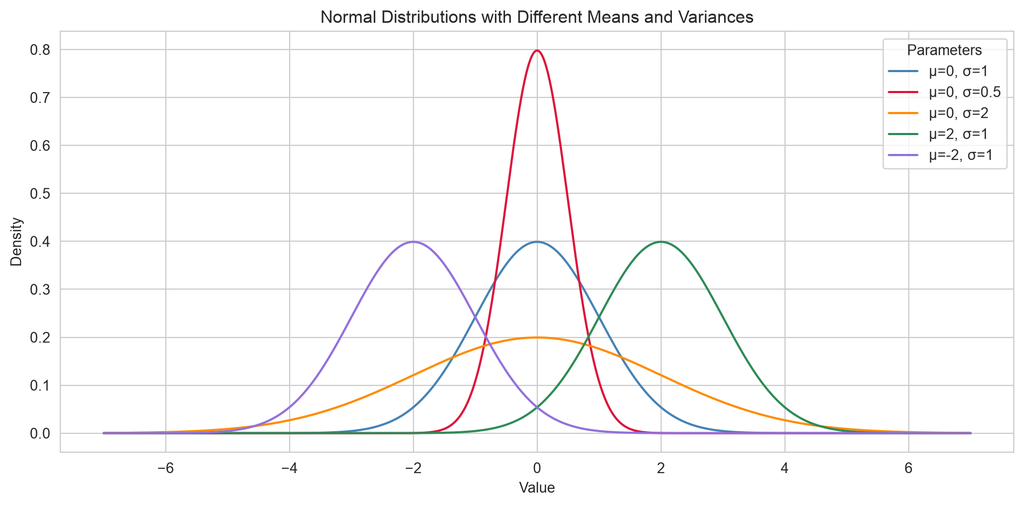

Bell curve example with different means and variances.

# Multivariate Analysis

## Cross Tabulation

### What are our aims?

- Find and measure relationships between variables.

### Categorical Cross Tabulation

- A **cross tabulation** displays the frequency distribution of two or more categorical variables.
- Examines the relationship between the variables by showing how the categories of one variable are distributed across the categories of another variable.

```python
pd.crosstab(
  titanic['class'], titanic['survived'],
  margins=True, normalize='index')
```

| survived class | 0 | 1 |
| --- | --- | --- |
| First | 0.370370 | 0.629630 |
| Second | 0.527174 | 0.472826 |
| Third | 0.757637 | 0.242363 |
| All | 0.616162 | 0.383838 |

## Tabulation of Categorical and Quantitative Variables

### What about when one variable is quantitative?

- We can use **grouped summary statistics** to examine the relationship between a categorical variable and a quantitative variable.
  - For example, we can compute the mean age of passengers in each class in the Titanic dataset.

### Mixed Type Tabulation Example

```python
titanic.groupby('class')['age'].describe()
```

| class | count | mean | std | min | 25% | 50% | 75% | max |
| --- | --- | --- | --- | --- | --- | --- | --- | --- |
| First | 186.0 | 38.233441 | 14.802856 | 0.92 | 27.0 | 37.0 | 49.0 | 80.0 |
| Second | 173.0 | 29.877630 | 14.001077 | 0.67 | 23.0 | 29.0 | 36.0 | 70.0 |
| Third | 355.0 | 25.140620 | 12.495398 | 0.42 | 18.0 | 24.0 | 32.0 | 74.0 |

## Covariance

### Multiple Quantitative Variables

- For two quantitative variables we are primarily interested in the sample covariance and correlation.

### Sample Covariance

- The **sample covariance** between two variables $X$ and $Y$ is calculated as:
  $$s_{XY} := \frac{1}{n-1} \sum_{i=1}^n (x_i - \bar{x})(y_i - \bar{y}).$$
  - This can be thought of as the average product of the deviations of the two variables from their respective means.
  - A **positive covariance** indicates that the variables tend to increase together
  - A **negative covariance** indicates that one variable tends to increase when the other decreases.

## Correlation

### Sample Correlation

- The **sample correlation** between two variables $X$ and $Y$ is calculated as:
  $$r_{XY} := \frac{s_{XY}}{s_X s_Y},$$
  where $s_X$ and $s_Y$ are the sample standard deviations of $X$ and $Y$, respectively.
  - The **correlation coefficient** ranges from -1 to 1.
  - Values close to 1 indicate a **strong positive linear relationship**.
  - Values close to -1 indicate a **strong negative linear relationship**.
  - Values close to 0 indicate **no linear relationship**.

## Warnings about Correlation

### Correlation is not causation!

- Correlation does not imply causation!
  - Just because two variables move together does not mean that one variable causes the other to move.
  - For example, there is a strong correlation between ice cream sales and crime rates, but it does not mean that ice cream sales causes crime or vice versa.

### Correlation measures linear relationships!

- Correlation measures only linear relationships!
  - Just because two variables have a correlation of 0 does not mean that they are independent.

## Non-Linear Relationships

### Look at the following scatter plot:

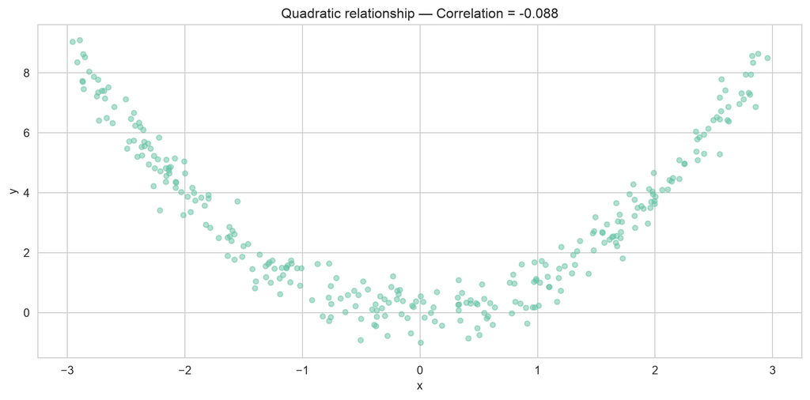

Quadratic relationship with a correlation of nearly 0.

- The correlation is nearly 0, but there is clearly a strong relationship.

## Covariance and Correlation Matrices

### Covariance and Correlation Matrices

- The **covariance matrix** of a set of variables is a square matrix that contains the variances and covariances of the variables.
- The **correlation matrix** of a set of variables is a square matrix that contains the correlations of the variables.
  - Both are symmetric and positive semi-definite (which means all eigenvalues are non-negative).

### Covariance and Correlation Matrices Example

```python
titanic[['age', 'fare']].cov()
```

|  | age | fare |
| --- | --- | --- |
| age | 211.019125 | 73.849030 |
| fare | 73.849030 | 2469.436846 |

```python
titanic[['age', 'fare']].corr()
```

|  | age | fare |
| --- | --- | --- |
| age | 1.000000 | 0.096067 |
| fare | 0.096067 | 1.000000 |

## Checking our Matrices

### Let’s look at the scatter plot

```python
fig, ax = plt.subplots(figsize=(10, 5))
sns.scatterplot(data=titanic, x='age', y='fare', ax=ax)
ax.set(
  title='Scatter Plot of Age and Fare',
  xlabel='Age',
  ylabel='Fare'
)
plt.tight_layout()
plt.show()
```

## Checking our Matrices

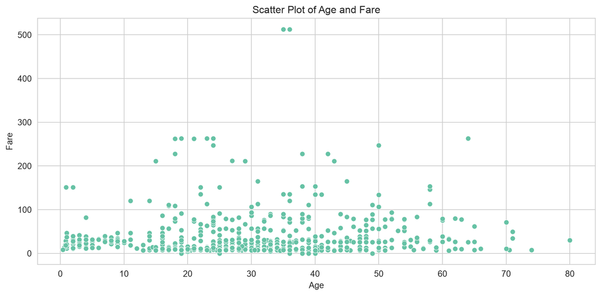

Scatter Plot of Age and Fare

# Exploratory Analysis Example

## Example Data: Wine Dataset

- We consider the wine data set provided by Geeks for Geeks in the following note on [Exploratory Data Analysis in Python](https://www.geeksforgeeks.org/exploratory-data-analysis-in-python/).

```python
wine = pd.read_csv('data/WineQT.csv')
wine.head()
```

|  | fixed acidity | volatile acidity | citric acid | residual sugar | chlorides | free sulfur dioxide | total sulfur dioxide | density | pH | sulphates | alcohol | quality | Id |
| --- | --- | --- | --- | --- | --- | --- | --- | --- | --- | --- | --- | --- | --- |
| 0 | 7.4 | 0.70 | 0.00 | 1.9 | 0.076 | 11.0 | 34.0 | 0.9978 | 3.51 | 0.56 | 9.4 | 5 | 0 |
| 1 | 7.8 | 0.88 | 0.00 | 2.6 | 0.098 | 25.0 | 67.0 | 0.9968 | 3.20 | 0.68 | 9.8 | 5 | 1 |
| 2 | 7.8 | 0.76 | 0.04 | 2.3 | 0.092 | 15.0 | 54.0 | 0.9970 | 3.26 | 0.65 | 9.8 | 5 | 2 |
| 3 | 11.2 | 0.28 | 0.56 | 1.9 | 0.075 | 17.0 | 60.0 | 0.9980 | 3.16 | 0.58 | 9.8 | 6 | 3 |
| 4 | 7.4 | 0.70 | 0.00 | 1.9 | 0.076 | 11.0 | 34.0 | 0.9978 | 3.51 | 0.56 | 9.4 | 5 | 4 |

- The shape of the wine dataset is:

```python
wine.shape
```

```
(1143, 13)
```

## Summary Statistics

- We can compute the summary statistics for the wine dataset using the `describe` method.

```python
wine.describe()
```

|  | fixed acidity | volatile acidity | citric acid | residual sugar | chlorides | free sulfur dioxide | total sulfur dioxide | density | pH | sulphates | alcohol | quality | Id |
| --- | --- | --- | --- | --- | --- | --- | --- | --- | --- | --- | --- | --- | --- |
| count | 1143.000000 | 1143.000000 | 1143.000000 | 1143.000000 | 1143.000000 | 1143.000000 | 1143.000000 | 1143.000000 | 1143.000000 | 1143.000000 | 1143.000000 | 1143.000000 | 1143.000000 |
| mean | 8.311111 | 0.531339 | 0.268364 | 2.532152 | 0.086933 | 15.615486 | 45.914698 | 0.996730 | 3.311015 | 0.657708 | 10.442111 | 5.657043 | 804.969379 |
| std | 1.747595 | 0.179633 | 0.196686 | 1.355917 | 0.047267 | 10.250486 | 32.782130 | 0.001925 | 0.156664 | 0.170399 | 1.082196 | 0.805824 | 463.997116 |
| min | 4.600000 | 0.120000 | 0.000000 | 0.900000 | 0.012000 | 1.000000 | 6.000000 | 0.990070 | 2.740000 | 0.330000 | 8.400000 | 3.000000 | 0.000000 |
| 25% | 7.100000 | 0.392500 | 0.090000 | 1.900000 | 0.070000 | 7.000000 | 21.000000 | 0.995570 | 3.205000 | 0.550000 | 9.500000 | 5.000000 | 411.000000 |
| 50% | 7.900000 | 0.520000 | 0.250000 | 2.200000 | 0.079000 | 13.000000 | 37.000000 | 0.996680 | 3.310000 | 0.620000 | 10.200000 | 6.000000 | 794.000000 |
| 75% | 9.100000 | 0.640000 | 0.420000 | 2.600000 | 0.090000 | 21.000000 | 61.000000 | 0.997845 | 3.400000 | 0.730000 | 11.100000 | 6.000000 | 1209.500000 |
| max | 15.900000 | 1.580000 | 1.000000 | 15.500000 | 0.611000 | 68.000000 | 289.000000 | 1.003690 | 4.010000 | 2.000000 | 14.900000 | 8.000000 | 1597.000000 |

## Univariate Analysis

### Histograms to inspect the distribution of the variables

```python
for feature in wine.columns:
    fig, ax = plt.subplots(figsize=(10, 5))
    sns.histplot(wine[feature], kde=True, ax=ax)
    plt.title(f"{feature} | Skewness: {round(wine[feature].skew(), 2)}")
    plt.savefig(f"assets/wine_{feature}.png")

plt.tight_layout()
plt.show()
```

## Histogram Plots

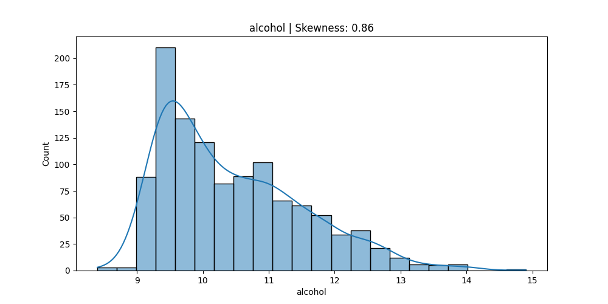

- Which variables are skewed?

## Skewness and Kurtosis

### Skewness

```python
wine.skew()
```

```
fixed acidity           1.044930
volatile acidity        0.681547
citric acid             0.371561
residual sugar          4.361096
chlorides               6.026360
free sulfur dioxide     1.231261
total sulfur dioxide    1.665766
density                 0.102395
pH                      0.221138
sulphates               2.497266
alcohol                 0.863313
quality                 0.286792
Id                     -0.010419
dtype: float64
```

### Kurtosis

```python
wine.kurtosis()
```

```
fixed acidity            1.384614
volatile acidity         1.375531
citric acid             -0.714686
residual sugar          27.675366
chlorides               47.078324
free sulfur dioxide      1.932170
total sulfur dioxide     5.098748
density                  0.888123
pH                       0.925791
sulphates               12.017377
alcohol                  0.221179
quality                  0.314664
Id                      -1.216364
dtype: float64
```

## Bivariate Analysis

### Pairplots

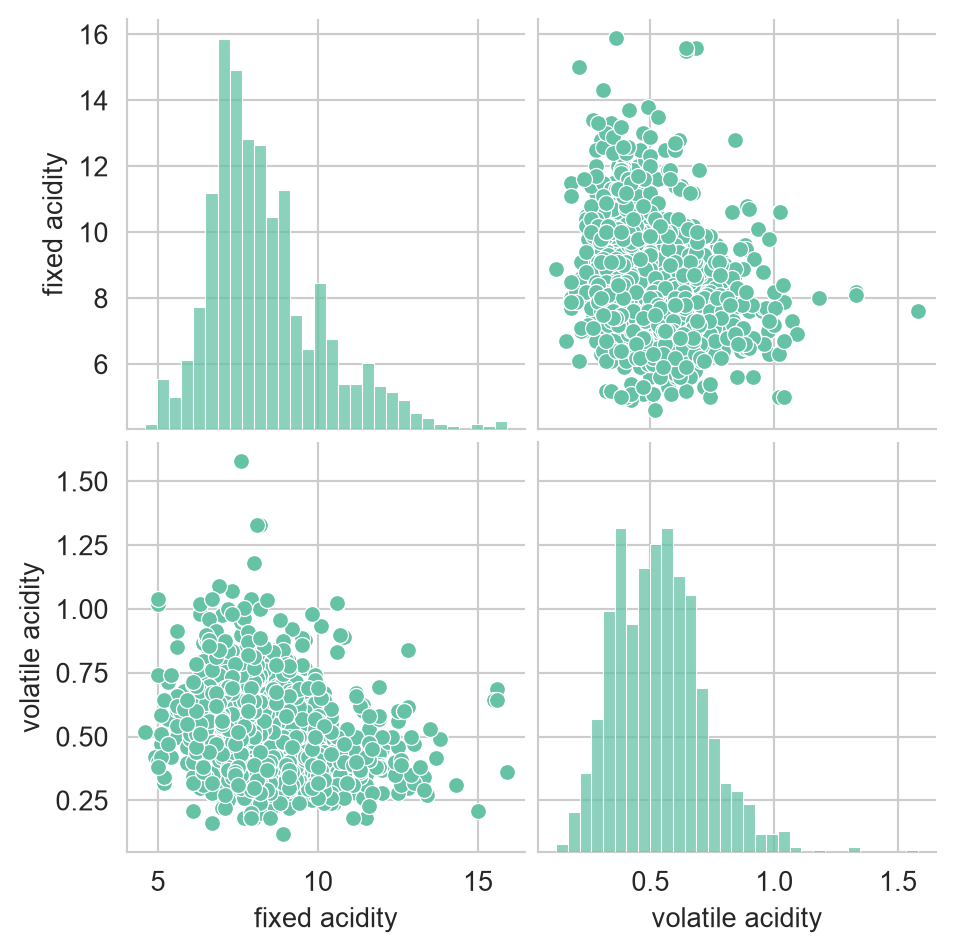

```python
sns.pairplot(wine.iloc[:, :2])
```

## Quality vs Alcohol

### Box Plots

```python
fig, ax = plt.subplots(figsize=(10, 5))
sns.boxplot(x='quality', y='alcohol', data=wine, ax=ax)
ax.set(
  title='Box Plot of Quality and Alcohol',
  xlabel='Quality',
  ylabel='Alcohol'
)
plt.tight_layout()
plt.show()
```

## Quality vs Alcohol

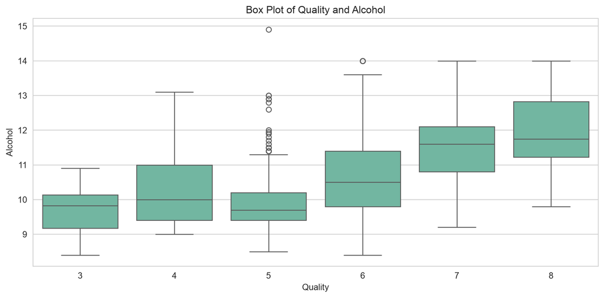

Box Plot of Quality and Alcohol

## Multivariate Analysis

### Heatmap

```python
plt.figure(figsize=(7, 7))

sns.heatmap(wine.corr(), annot=True, fmt='.2f', cmap='Pastel2', linewidths=2)
plt.title('Correlation Heatmap')
plt.show()
```

## Multivariate Analysis

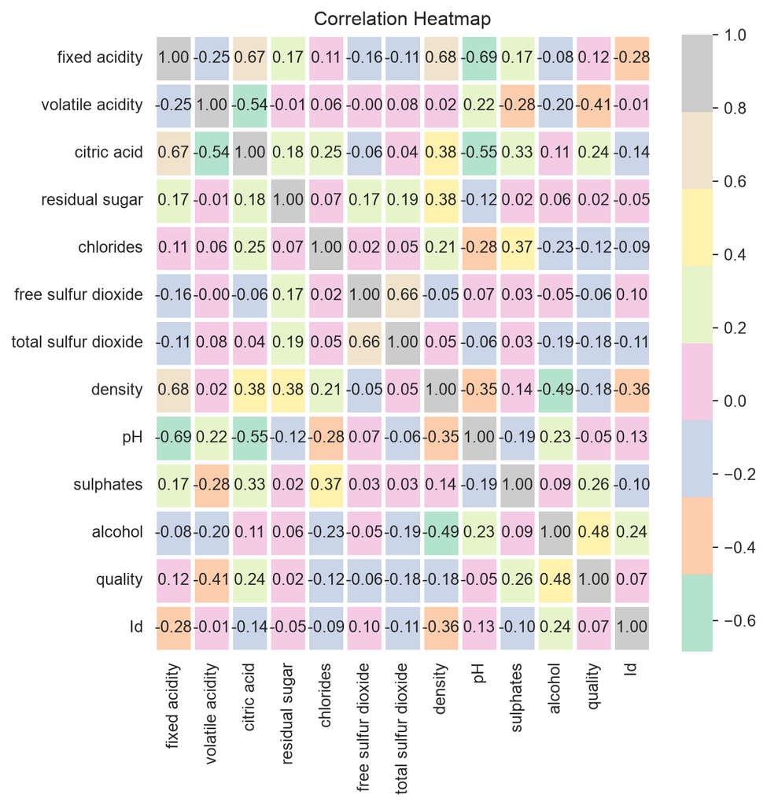

Heatmap of the wine dataset

## Conclusion

### ✅ What we covered

- Exploratory Data Analysis (EDA):
  - Univariate analysis.
  - Bivariate analysis.
  - Multivariate analysis.
  - Correlation and covariance.
  - Skewness and kurtosis.
  - Cross tabulation.
  - Grouped summary statistics.
  - Mixed type tabulation.

### 📅 What’s next?

- Statistical Foundations.
- Probability and Distributions.